# 5. RNA-seq analysis

## Purpose

This script runs differential expression analysis on the RNA-seq data across the four outcomes using DESeq2, producing the `deg_*.tsv` files (Table S7 to S10) and the FDR-adjusted volcano plots (Fig. 2). It also runs the cell-type deconvolution statistical analysis (Wilcoxon tests per cell type, BH-corrected within each outcome), reproducing Table S11 and Fig. S2.

## Reproducibility

This script runs entirely from the public repository. Only `rnaseq_transcriptomics_counts.tsv`, `metadata.tsv`, and `cell_deconvolution_sid.csv` are needed.

```r
library(AnnotationDbi)
library(biomaRt)
library(org.Hs.eg.db)
library(DESeq2)
library(ggpubr)
library(ggrepel)
library(pheatmap)
library(RColorBrewer)
library(tidyverse)
```

## Data generation

RNA-seq reads were processed with nf-core/rnaseq v3.17.0, using STAR/RSEM for alignment and quantification, against the GRCh38.112 Ensembl reference. `rnaseq_transcriptomics_counts.tsv` is derived from the pipeline’s `rsem.merged.gene_counts.tsv` output.

```bash
nextflow run \
    nf-core/rnaseq -r 3.17.0 \
    --input "samplesheet.csv" \
    --outdir "results" \
    --gtf "Homo_sapiens.GRCh38.112.gtf.gz" \
    --fasta "Homo_sapiens.GRCh38.dna_sm.primary_assembly.fa.gz" \
    --aligner "star_rsem" \
    --igenomes_ignore \
    --genome null \
    -profile singularity \
    -c nextflow.config
```

Reference files (`Homo_sapiens.GRCh38.112.gtf.gz`, `Homo_sapiens.GRCh38.dna_sm.primary_assembly.fa.gz`) are the standard Ensembl release 112 GRCh38 assembly, publicly available from Ensembl.

## Load public data and build the dds object

Raw RNA-seq counts (genes x samples) and the public metadata file are combined here to build the `DESeqDataSet` from scratch.

```r
counts_mat <- read_tsv("../data/rnaseq_transcriptomics_counts.tsv") |>
    column_to_rownames("gene_ensembl_id") |>
    as.matrix()
```

```r
coldata <- read_tsv("../data/metadata.tsv") |>
    filter(sid %in% colnames(counts_mat)) |>
    column_to_rownames("sid")

coldata <- coldata[colnames(counts_mat), , drop = FALSE] # match sample order
```

```r
stopifnot(all(colnames(counts_mat) == rownames(coldata))) # Must be TRUE
```

```r
dds <- DESeqDataSetFromMatrix(
    countData = round(counts_mat),
    colData   = coldata,
    design    = ~1
)
```

## dds inspection

```r
head(counts(dds)) # to check the raw counts
```

```
                PTY_001 PTY_003 PTY_004 PTY_005 PTY_006 PTY_007 PTY_008 PTY_009
ENSG00000000003      10       6      23       5       0      11      11       4
ENSG00000000005       0       0       0       0       0       0       0       0
ENSG00000000419     452     582    1465     410     687     559     523     611
ENSG00000000457     235     326     477     116     168     149     160     146
ENSG00000000460      98      46      88      45      46      39      43      49
ENSG00000000938    6015    5741    9566    7065    7140    5568    9784   13625
                PTY_010 PTY_011 PTY_014 PTY_015 PTY_016 PTY_017 PTY_018 PTY_019
ENSG00000000003       6      12       0      16       0       9       1      10
ENSG00000000005       0       0       0       0       0       0       0       0
ENSG00000000419     482     644     552     482     456     558     560     361
ENSG00000000457     178     323     229     351     171     354     272     285
ENSG00000000460      37      87      76     106      67      80     101      91
ENSG00000000938   12333    9113    9417    9283   18539   11700   16111    9186
                PTY_020 PTY_024 PTY_025 PTY_026 PTY_027 PTY_028 PTY_029 PTY_030
ENSG00000000003       3      15       5       3       1       0       2       7
ENSG00000000005       0       0       0       0       0       0       0       0
ENSG00000000419     549     541     420     477     540     536     649     546
ENSG00000000457     219     241     214     256     212     128     104      76
ENSG00000000460      51      23      46      67      62      68      52      43
ENSG00000000938    9669    5204   13026   10165   13191   14017    6994    4428
                PTY_031 PTY_032 PTY_034 PTY_035 PTY_036 PTY_037 PTY_038 PTY_039
ENSG00000000003      11      24       0       0       1       9       3       5
ENSG00000000005       0       0       0       0       0       0       0       0
ENSG00000000419     508     648     596     224     598     902     710     411
ENSG00000000457     120     329     163     147     112     260     119     426
ENSG00000000460      16      15      55      50      59      21      89      23
ENSG00000000938    2547    2890   11484   17437    5473    3117    5596    2169
                PTY_040 PTY_041 PTY_042 PTY_044 PTY_045 PTY_046 PTY_048 PTY_049
ENSG00000000003       2      10      31       5       1       5       0      14
ENSG00000000005       0       0       0       0       0       0       0       0
ENSG00000000419     461     433     708     282     483     715     604     629
ENSG00000000457     100     103     311     181      56     192     185     355
ENSG00000000460      11      29      19      80      78      63      63      86
ENSG00000000938    6071    4979    2565   13559    9756    9936    9868    4826
                PTY_050 PTY_051 PTY_052 PTY_053 PTY_054 PTY_056 PTY_057 PTY_058
ENSG00000000003       3      16      15       8      12       3      17       4
ENSG00000000005       0       0       0       0       0       0       0       0
ENSG00000000419     573     554     406     523     887     300     593     692
ENSG00000000457     236     206     383     170     375     175     252     172
```

[output cut: 85 more lines]

```
ENSG00000000938    5596    4305    3365    2992    3462    5051    5785    3409
                PTY_176 PTY_177 PTY_178 PTY_179 PTY_180 PTY_181 PTY_182 PTY_183
ENSG00000000003       1      12       0       1      13       0       2       2
ENSG00000000005       0       0       0       0       0       0       0       0
ENSG00000000419     378     640      23     244     755     248     365     326
ENSG00000000457      70     362       0     107     182     310     145     129
ENSG00000000460      32      15       0      43      24      60      48      84
ENSG00000000938    7739    3501     191   13142    4054   12723   10644   13047
                PTY_184 PTY_185 PTY_187
ENSG00000000003      10       4       2
ENSG00000000005       0       0       0
ENSG00000000419     639     519     690
ENSG00000000457     233     155     126
ENSG00000000460      68      33      68
ENSG00000000938    2519    6556    5217
```

```r
colData(dds) # to check the sample info
```

```
DataFrame with 155 rows and 26 columns
              group      nadm      mace death_all       age         sex
        <character> <numeric> <numeric> <numeric> <logical> <character>
PTY_001     Control         0         0         0        NA        Male
PTY_003     Control         0         0         0        NA        Male
PTY_004       Event         1         0         0        NA        Male
PTY_005       Event         1         0         0        NA        Male
PTY_006       Event         0         1         0        NA        Male
...             ...       ...       ...       ...       ...         ...
PTY_182       Event         1         0         0        NA      Female
PTY_183       Event         0         1         1        NA      Female
PTY_184       Event         1         0         1        NA      Female
PTY_185     Control         0         0         0        NA      Female
PTY_187     Control         0         0         0        NA      Female
             mode paisorigen           edulvl     smoke       hta
        <logical>  <logical>      <character> <numeric> <numeric>
PTY_001        NA         NA      High school         0        NA
PTY_003        NA         NA       University         1        NA
PTY_004        NA         NA       University         0        NA
PTY_005        NA         NA      High school         1         1
PTY_006        NA         NA   Primary school         1         1
...           ...        ...              ...       ...       ...
PTY_182        NA         NA      High school         1         1
PTY_183        NA         NA Secondary school         0         1
PTY_184        NA         NA Secondary school         1         1
PTY_185        NA         NA Secondary school        NA        NA
PTY_187        NA         NA      High school        NA        NA
                 art_reg     cvmax  nadircd4     CD4_0     CD8_0  CD4CD8_0
             <character> <numeric> <numeric> <numeric> <numeric> <numeric>
PTY_001    2 NRTI + 1 PI    467100       207       298      1144  0.260490
PTY_003 2 NRTI + 1 NNRTI     66640       837       837      1129  0.741364
PTY_004            Other    110972       416       421      1964  0.214358
PTY_005    2 NRTI + 1 PI    204932       126       126       513  0.245614
PTY_006 2 NRTI + 1 INSTI    113700        55        55       515  0.106796
...                  ...       ...       ...       ...       ...       ...
PTY_182    2 NRTI + 1 PI   1000000       140       228       964  0.236515
PTY_183 2 NRTI + 1 NNRTI    117527       200       200       700  0.285714
PTY_184 2 NRTI + 1 NNRTI    189170       190       250      1810  0.138122
PTY_185 2 NRTI + 1 NNRTI     19000        NA        NA        NA  0.409268
PTY_187    2 NRTI + 1 PI   2000000        NA        NA        NA  0.409268
```

[output cut: 11 more lines]

```
PTY_185        NA        NA        NA             26.5161            NA
PTY_187        NA        NA        NA             26.8387            NA
           sid_pair      time olink_included rnaseq_included
        <character> <numeric>      <numeric>       <numeric>
PTY_001     PTY_015        10              1               1
PTY_003     PTY_049        41              1               1
PTY_004     PTY_032        31              1               1
PTY_005     PTY_075        21              1               1
PTY_006     PTY_041         6              1               1
...             ...       ...            ...             ...
PTY_182     PTY_185       111              0               1
PTY_183     PTY_176        50              1               1
PTY_184     PTY_132        24              1               1
PTY_185     PTY_182         4              0               1
PTY_187     PTY_133        29              0               1
```

```r
design(dds) # to check the design formula
```

```
~1
```

## Pre-filtering

```r
smallestGroupSize <- 3

keep <- rowSums(counts(dds) >= 10) >= smallestGroupSize
dds_filtered <- dds[keep, ]
```

## Help functions

```r
# A function to run DESeq2
run_deseq <- function(dds, design_var) {
    dds_tmp <- DESeqDataSet(dds, design = as.formula(paste0("~ ", design_var)))
    dds_tmp <- DESeq(dds_tmp)
    res <- results(dds_tmp)
    list(dds = dds_tmp, res = res)
}
```

```r
# A function for Ensembl annotation
annotate_genes <- function(ensembl_ids) {
    mart <- useEnsembl("genes", "hsapiens_gene_ensembl")

    getBM(
        attributes = c(
            "ensembl_gene_id",
            "external_gene_name",
            "description",
            "gene_biotype"
        ),
        filters = "ensembl_gene_id",
        values = unique(ensembl_ids),
        mart = mart
    )
}
```

```r
tidy_results <- function(res, lfc = 0, alpha = 0.05, filter_sig = TRUE) {

    # 1. Convert DESeq2 results to tibble and classify genes
    res_tb <- as_tibble(res) |>
        mutate(
            gene = rownames(res),
            diffexpressed = case_when(
                log2FoldChange >  lfc & padj < alpha ~ "upregulated",
                log2FoldChange < -lfc & padj < alpha ~ "downregulated",
                TRUE ~ "not_de"
            )
        ) |>
        relocate(gene)

    # 2. Annotate ALL genes
    annot <- annotate_genes(res_tb$gene) |>
        mutate(
            description = sub("\\s*\\[.*\\]$", "", description)
        )

    # 3. Join annotation
    res_tb <- res_tb |>
        left_join(
            annot,
            by = c("gene" = "ensembl_gene_id")
        ) |>
        arrange(pvalue)

    # 4. Optionally filter significant genes
    if (filter_sig) {
        res_tb <- res_tb |> filter(padj < alpha)
    }

    return(res_tb)
}
```

```r
# FDR-adjusted volcano plot
plot_volcano_fdr <- function(
        res_tb,
        title,
        lfc_cutoff = 1,
        fdr_cutoff = 0.05,
        label_pc_only = TRUE
) {
    cols <- c("upregulated" = "#ffad73", "downregulated" = "#26b3ff", "not_de" = "grey")
    alphas <- c("upregulated" = 1, "downregulated" = 1, "not_de" = 0.5)

    plot_tb <- res_tb |>
        mutate(
            genelabels = ifelse(
                diffexpressed != "not_de" &
                    (!label_pc_only | gene_biotype == "protein_coding"),
                external_gene_name,
                ""
            )
        )
    xmax <- max(abs(plot_tb$log2FoldChange), na.rm = TRUE)

    ggplot(
        plot_tb,
        aes(x = log2FoldChange, y = -log10(padj), fill = diffexpressed, alpha = diffexpressed)
    ) +
        geom_point(shape = 21, colour = "black") +
        geom_vline(xintercept = c(-lfc_cutoff, lfc_cutoff), linetype = "dashed",
                   linewidth = 0.2, colour = "black") +
        geom_hline(yintercept = -log10(fdr_cutoff), linetype = "dashed") +
        scale_fill_manual(values = cols, name = "Differential expression",
                          breaks = c("upregulated", "downregulated", "not_de"),
                          labels = c("Up", "Down", "n.s.")) +
        scale_alpha_manual(values = alphas) +
        scale_x_continuous(limits = c(-xmax, xmax)) +
        theme_bw() +
        theme(legend.position = "bottom",
              legend.background = element_rect(colour = "black", linewidth = 0.5),
              axis.title = element_text(size = 9)) +
        labs(title = title, x = expression(log[2](FC)),
             y = expression(-log[10]("FDR-adjusted P value"))) +
        guides(alpha = "none")
}
```

## Run analyses

```r
res_group      <- run_deseq(dds_filtered, "group")
```

```
-- replacing outliers and refitting for 262 genes
-- DESeq argument 'minReplicatesForReplace' = 7
-- original counts are preserved in counts(dds)
```

```r
res_nadm       <- run_deseq(dds_filtered, "nadm")
```

```
  the design formula contains one or more numeric variables with integer values,
  specifying a model with increasing fold change for higher values.
  did you mean for this to be a factor? if so, first convert
  this variable to a factor using the factor() function
```

```
-- replacing outliers and refitting for 235 genes
-- DESeq argument 'minReplicatesForReplace' = 7
-- original counts are preserved in counts(dds)
```

```r
res_mace       <- run_deseq(dds_filtered, "mace")
```

```
  the design formula contains one or more numeric variables with integer values,
  specifying a model with increasing fold change for higher values.
  did you mean for this to be a factor? if so, first convert
  this variable to a factor using the factor() function
```

```
-- replacing outliers and refitting for 257 genes
-- DESeq argument 'minReplicatesForReplace' = 7
-- original counts are preserved in counts(dds)
```

```r
res_death_all  <- run_deseq(dds_filtered, "death_all")
```

```
  the design formula contains one or more numeric variables with integer values,
  specifying a model with increasing fold change for higher values.
  did you mean for this to be a factor? if so, first convert
  this variable to a factor using the factor() function
```

```
-- replacing outliers and refitting for 270 genes
-- DESeq argument 'minReplicatesForReplace' = 7
-- original counts are preserved in counts(dds)
```

## Tidy + plot

```r
tb_group <- tidy_results(res_group$res, filter_sig = FALSE)
```

```
Ensembl site unresponsive, trying useast mirror
```

```
Ensembl site unresponsive, trying asia mirror
```

```r
tb_group
```

| gene | baseMean | log2FoldChange | lfcSE | stat | pvalue | padj | diffexpressed | external_gene_name | description | gene_biotype |
| --- | --- | --- | --- | --- | --- | --- | --- | --- | --- | --- |
| ENSG00000184979 | 1.383370e+02 | 1.54533126 | 0.21224955 | 7.2807280 | 3.320236e-13 | 5.959159e-09 | upregulated | USP18 | ubiquitin specific peptidase 18 | protein_coding |
| ENSG00000187608 | 1.775246e+03 | 1.12874991 | 0.18479209 | 6.1082157 | 1.007511e-09 | 9.041408e-06 | upregulated | ISG15 | ISG15 ubiquitin like modifier | protein_coding |
| ENSG00000230202 | 6.582558e+01 | 1.21840858 | 0.21696665 | 5.6156492 | 1.958256e-08 | 1.171559e-04 | upregulated | RPL29P4 | ribosomal protein L29 pseudogene 4 | processed_pseudogene |
| ENSG00000088827 | 7.576050e+02 | 1.40548495 | 0.28471678 | 4.9364317 | 7.956487e-07 | 3.570076e-03 | upregulated | SIGLEC1 | sialic acid binding Ig like lectin 1 | protein_coding |
| ENSG00000163666 | 6.153039e+00 | 1.47141661 | 0.30438761 | 4.8340226 | 1.338014e-06 | 4.802934e-03 | upregulated | HESX1 | HESX homeobox 1 | protein_coding |
| ENSG00000049247 | 9.681372e+00 | -1.59276602 | 0.34487848 | -4.6183399 | 3.868223e-06 | 9.718608e-03 | downregulated | UTS2 | urotensin 2 | protein_coding |
| ENSG00000225972 | 1.318519e+01 | -1.42755570 | 0.31049904 | -4.5976171 | 4.273504e-06 | 9.718608e-03 | downregulated | MTND1P23 | MT-ND1 pseudogene 23 | unprocessed_pseudogene |
| ENSG00000165949 | 1.204410e+02 | 1.81121539 | 0.39418911 | 4.5947880 | 4.331895e-06 | 9.718608e-03 | upregulated | IFI27 | interferon alpha inducible protein 27 | protein_coding |
| ENSG00000115155 | 3.692407e+01 | 1.12597724 | 0.24676715 | 4.5629139 | 5.044851e-06 | 1.006055e-02 | upregulated | OTOF | otoferlin | protein_coding |
| ENSG00000111331 | 1.728268e+03 | 0.94944653 | 0.21673619 | 4.3806553 | 1.183229e-05 | 2.123660e-02 | upregulated | OAS3 | 2'-5'-oligoadenylate synthetase 3 | protein_coding |

[output cut: 9990 more lines]

```r
tb_nadm  <- tidy_results(res_nadm$res, filter_sig = FALSE)
```

```
Ensembl site unresponsive, trying useast mirror
Ensembl site unresponsive, trying asia mirror
```

```r
tb_nadm
```

| gene | baseMean | log2FoldChange | lfcSE | stat | pvalue | padj | diffexpressed | external_gene_name | description | gene_biotype |
| --- | --- | --- | --- | --- | --- | --- | --- | --- | --- | --- |
| ENSG00000184979 | 1.383370e+02 | 1.35269381 | 0.23445675 | 5.7694813 | 7.951590e-09 | 0.0001547141 | upregulated | USP18 | ubiquitin specific peptidase 18 | protein_coding |
| ENSG00000087245 | 1.575699e+01 | -1.87832432 | 0.33546289 | -5.5992015 | 2.153414e-08 | 0.0002094949 | downregulated | MMP2 | matrix metallopeptidase 2 | protein_coding |
| ENSG00000144476 | 1.184635e+02 | -1.41674163 | 0.28223437 | -5.0197345 | 5.174294e-07 | 0.0033558746 | downregulated | ACKR3 | atypical chemokine receptor 3 | protein_coding |
| ENSG00000106366 | 2.425791e+02 | -1.70219368 | 0.34916130 | -4.8750927 | 1.087574e-06 | 0.0052902308 | downregulated | SERPINE1 | serpin family E member 1 | protein_coding |
| ENSG00000113657 | 1.693355e+01 | -1.41582512 | 0.29922363 | -4.7316621 | 2.226888e-06 | 0.0086657138 | downregulated | DPYSL3 | dihydropyrimidinase like 3 | protein_coding |
| ENSG00000173391 | 2.692378e+02 | -2.04525156 | 0.43672753 | -4.6831294 | 2.825280e-06 | 0.0091619115 | downregulated | OLR1 | oxidized low density lipoprotein receptor 1 | protein_coding |
| ENSG00000107719 | 1.103650e+02 | -1.02190420 | 0.22178487 | -4.6076371 | 4.072706e-06 | 0.0113203764 | downregulated | PALD1 | phosphatase domain containing paladin 1 | protein_coding |
| ENSG00000214456 | 1.643247e+01 | -1.50905757 | 0.33052295 | -4.5656665 | 4.979098e-06 | 0.0121097879 | downregulated | PLIN5 | perilipin 5 | protein_coding |
| ENSG00000167772 | 1.177899e+01 | -2.47932255 | 0.56970618 | -4.3519320 | 1.349431e-05 | 0.0271130257 | downregulated | ANGPTL4 | angiopoietin like 4 | protein_coding |
| ENSG00000169902 | 6.585400e+01 | -0.92551354 | 0.21378391 | -4.3292010 | 1.496513e-05 | 0.0271130257 | downregulated | TPST1 | tyrosylprotein sulfotransferase 1 | protein_coding |

[output cut: 9990 more lines]

```r
tb_mace  <- tidy_results(res_mace$res, filter_sig = FALSE)
```

```
Ensembl site unresponsive, trying asia mirror
```

```r
tb_mace
```

| gene | baseMean | log2FoldChange | lfcSE | stat | pvalue | padj | diffexpressed | external_gene_name | description | gene_biotype |
| --- | --- | --- | --- | --- | --- | --- | --- | --- | --- | --- |
| ENSG00000197632 | 4.864167e+02 | 2.26642489 | 0.42822926 | 5.2925502 | 1.206223e-07 | 0.002164929 | upregulated | SERPINB2 | serpin family B member 2 | protein_coding |
| ENSG00000179630 | 7.548425e+01 | 0.81219031 | 0.17065618 | 4.7592201 | 1.943424e-06 | 0.013462798 | upregulated | LACC1 | laccase domain containing 1 | protein_coding |
| ENSG00000156535 | 7.234312e+01 | 1.21002716 | 0.25878906 | 4.6757276 | 2.929132e-06 | 0.013462798 | upregulated | CD109 | CD109 molecule | protein_coding |
| ENSG00000136235 | 1.182806e+02 | 1.66677081 | 0.35841135 | 4.6504410 | 3.312260e-06 | 0.013462798 | upregulated | GPNMB | glycoprotein nmb | protein_coding |
| ENSG00000183019 | 4.535291e+02 | 0.87024521 | 0.18817129 | 4.6247502 | 3.750501e-06 | 0.013462798 | upregulated | MCEMP1 | mast cell expressed membrane protein 1 | protein_coding |
| ENSG00000087245 | 1.575699e+01 | 1.97559047 | 0.43302902 | 4.5622588 | 5.060622e-06 | 0.013736440 | upregulated | MMP2 | matrix metallopeptidase 2 | protein_coding |
| ENSG00000144476 | 1.184635e+02 | 1.68323818 | 0.36991959 | 4.5502812 | 5.357426e-06 | 0.013736440 | upregulated | ACKR3 | atypical chemokine receptor 3 | protein_coding |
| ENSG00000166033 | 6.027191e+01 | 1.17391070 | 0.26166186 | 4.4863653 | 7.244847e-06 | 0.015283199 | upregulated | HTRA1 | HtrA serine peptidase 1 | protein_coding |
| ENSG00000105976 | 5.591291e+00 | 2.42404582 | 0.54215188 | 4.4711563 | 7.779780e-06 | 0.015283199 | upregulated | MET | MET proto-oncogene, receptor tyrosine kinase | protein_coding |
| ENSG00000138061 | 2.055090e+03 | 1.46430728 | 0.32892462 | 4.4518020 | 8.515266e-06 | 0.015283199 | upregulated | CYP1B1 | cytochrome P450 family 1 subfamily B member 1 | protein_coding |

[output cut: 9990 more lines]

```r
tb_death <- tidy_results(res_death_all$res, filter_sig = FALSE)
```

```
Ensembl site unresponsive, trying asia mirror
```

```r
tb_death
```

| gene | baseMean | log2FoldChange | lfcSE | stat | pvalue | padj | diffexpressed | external_gene_name | description | gene_biotype |
| --- | --- | --- | --- | --- | --- | --- | --- | --- | --- | --- |
| ENSG00000173391 | 2.490656e+02 | -2.85953841 | 0.63013058 | -4.5380093 | 5.678776e-06 | 0.1104919 | not_de | OLR1 | oxidized low density lipoprotein receptor 1 | protein_coding |
| ENSG00000102962 | 1.060937e+01 | -2.66214507 | 0.65499290 | -4.0643877 | 4.815873e-05 | 0.2394110 | not_de | CCL22 | C-C motif chemokine ligand 22 | protein_coding |
| ENSG00000158966 | 2.548732e+01 | -1.42035059 | 0.35017169 | -4.0561548 | 4.988719e-05 | 0.2394110 | not_de | CACHD1 | cache domain containing 1 | protein_coding |
| ENSG00000106366 | 2.284256e+02 | -2.03129128 | 0.50665691 | -4.0092048 | 6.092357e-05 | 0.2394110 | not_de | SERPINE1 | serpin family E member 1 | protein_coding |
| ENSG00000182379 | 3.331595e+01 | -1.67644656 | 0.41839081 | -4.0068915 | 6.152311e-05 | 0.2394110 | not_de | NXPH4 | neurexophilin 4 | protein_coding |
| ENSG00000285103 | 1.278398e+01 | -1.32133965 | 0.33556791 | -3.9376221 | 8.229304e-05 | 0.2466404 | not_de | EMICERI | EQTN MOB3B IFNK C9orf72 enhancer RNA I | lncRNA |
| ENSG00000123094 | 1.535465e+01 | -1.14217740 | 0.29140903 | -3.9194990 | 8.873325e-05 | 0.2466404 | not_de | RASSF8 | Ras association domain family member 8 | protein_coding |
| ENSG00000256500 | 5.036986e+00 | -5.00614950 | 1.30154693 | -3.8463073 | 1.199113e-04 | 0.2916394 | not_de |  | novel protein | protein_coding |
| ENSG00000131016 | 8.861751e+00 | -1.75140223 | 0.45913725 | -3.8145505 | 1.364310e-04 | 0.2949487 | not_de | AKAP12 | A-kinase anchoring protein 12 | protein_coding |
| ENSG00000100600 | 4.154598e+02 | -1.19621163 | 0.31771001 | -3.7651053 | 1.664789e-04 | 0.3239180 | not_de | LGMN | legumain | protein_coding |

[output cut: 9990 more lines]

## Export results

```r
# tb_group |> write_tsv("../results/tableS7_deg_group.tsv")
# tb_nadm |> write_tsv("../results/tableS8_deg_nadm.tsv")
# tb_mace |> write_tsv("../results/tableS9_deg_mace.tsv")
# tb_death |> write_tsv("../results/tableS10_deg_death_all.tsv")
```

## Volcano plots

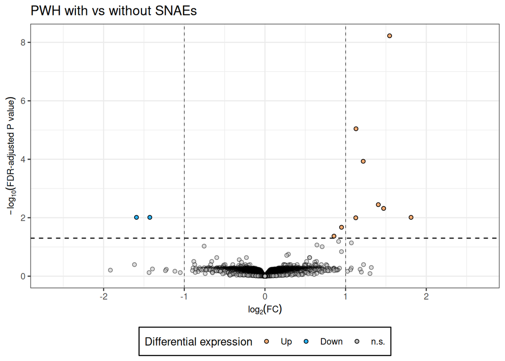

```r
pA <- plot_volcano_fdr(tb_group, "PWH with vs without SNAEs")
pA
```

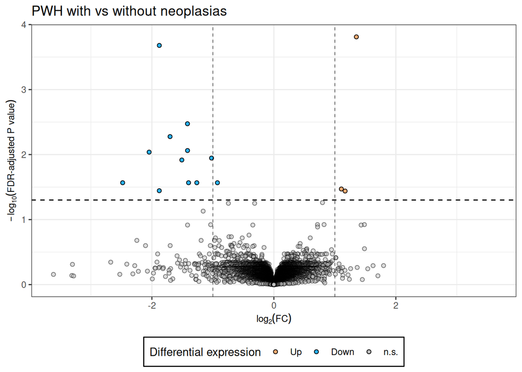

```r
pB <- plot_volcano_fdr(tb_nadm, "PWH with vs without neoplasias")
pB
```

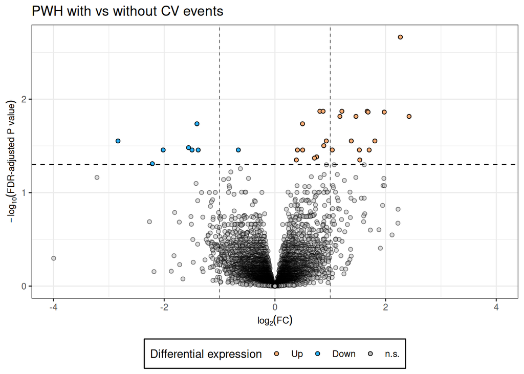

```r
pC <- plot_volcano_fdr(tb_mace, "PWH with vs without CV events")
pC
```

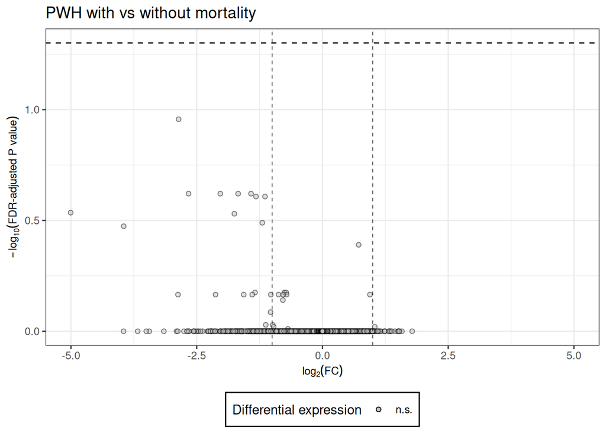

```r
pD <- plot_volcano_fdr(tb_death, "PWH with vs without mortality")
pD
```

All together in one figure:

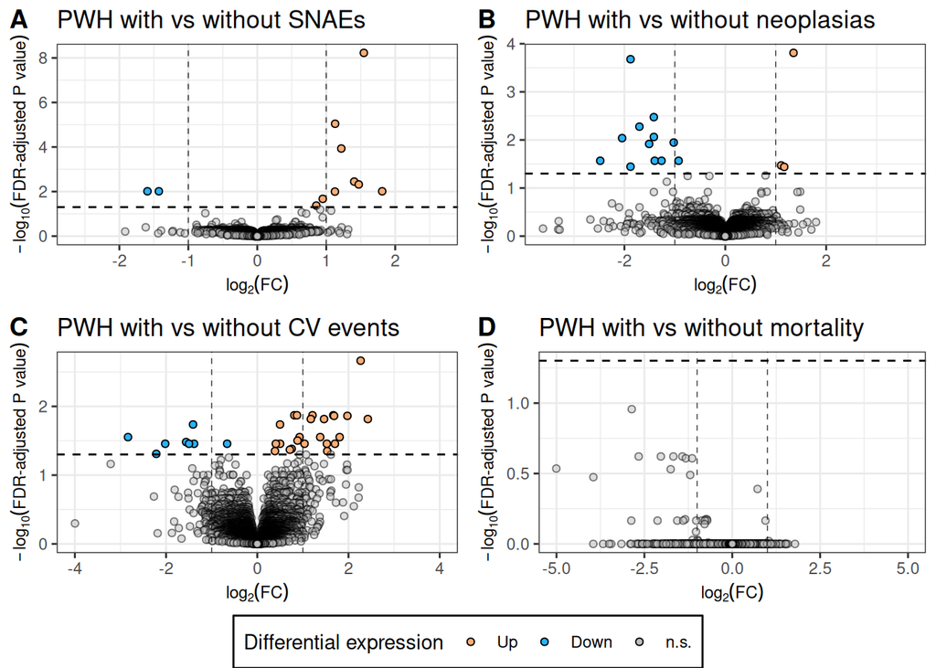

```r
# svg("../results/fig2_AtoD.svg", width = 7, height = 5)
ggarrange(pA, pB, pC, pD, labels = c("A", "B", "C", "D"),
          common.legend = TRUE, legend = "bottom")
```

```r
# dev.off()
```

## Cell deconvolution statistical analysis

This section reproduces the statistics reported in Table S11/Fig. S2 directly from the public deconvolution results file.

```r
deconv <- read_csv("../data/cell_deconvolution_sid.csv")
metadata <- read_tsv("../data/metadata.tsv")

outcomes <- c("group", "nadm", "mace", "death_all")
diagnostic_columns <- c("sid", "P-value", "Correlation", "RMSE")
cell_types <- setdiff(names(deconv), diagnostic_columns)
```

```r
fit_qc <- deconv |>
    summarise(
        samples = n(),
        cibersort_p_lt_0.001 = sum(`P-value` < 0.001),
        correlation_median = median(Correlation),
        correlation_q1 = quantile(Correlation, 0.25),
        correlation_q3 = quantile(Correlation, 0.75),
        rmse_median = median(RMSE),
        rmse_q1 = quantile(RMSE, 0.25),
        rmse_q3 = quantile(RMSE, 0.75)
    )
fit_qc
```

| samples | cibersort_p_lt_0.001 | correlation_median | correlation_q1 | correlation_q3 | rmse_median | rmse_q1 | rmse_q3 |
| --- | --- | --- | --- | --- | --- | --- | --- |
| 155 | 155 | 0.8111522 | 0.7852491 | 0.8363987 | 0.6518423 | 0.6263511 | 0.6709225 |

```r
celltype_qc <- deconv |>
    dplyr::select(all_of(cell_types)) |>
    pivot_longer(everything(), names_to = "cell_type", values_to = "cell_proportion") |>
    group_by(cell_type) |>
    summarise(
        mean_proportion = mean(cell_proportion),
        median_proportion = median(cell_proportion),
        q1_proportion = quantile(cell_proportion, 0.25),
        q3_proportion = quantile(cell_proportion, 0.75),
        nonzero_n = sum(cell_proportion > 0),
        zero_n = sum(cell_proportion == 0),
        zero_percent = 100 * mean(cell_proportion == 0),
        .groups = "drop"
    ) |>
    arrange(desc(mean_proportion))
celltype_qc
```

| cell_type | mean_proportion | median_proportion | q1_proportion | q3_proportion | nonzero_n | zero_n | zero_percent |
| --- | --- | --- | --- | --- | --- | --- | --- |
| T cells CD8 | 3.674352e-01 | 0.3650007916 | 0.296604873 | 0.4336990966 | 155 | 0 | 0.000000 |
| Monocytes | 2.897868e-01 | 0.2900102387 | 0.227376164 | 0.3489306612 | 155 | 0 | 0.000000 |
| NK cells resting | 8.190747e-02 | 0.0757449184 | 0.036622854 | 0.1152789731 | 150 | 5 | 3.225806 |
| B cells naive | 6.391196e-02 | 0.0583035914 | 0.037062563 | 0.0827866157 | 155 | 0 | 0.000000 |
| T cells CD4 memory resting | 4.341401e-02 | 0.0295056291 | 0.000000000 | 0.0661368236 | 109 | 46 | 29.677419 |
| NK cells activated | 3.807804e-02 | 0.0319855169 | 0.012549267 | 0.0566207126 | 136 | 19 | 12.258065 |
| Macrophages M2 | 3.107474e-02 | 0.0279315959 | 0.020100890 | 0.0415372871 | 155 | 0 | 0.000000 |
| T cells regulatory (Tregs) | 2.562961e-02 | 0.0237883045 | 0.012315503 | 0.0352174664 | 150 | 5 | 3.225806 |
| T cells CD4 memory activated | 1.294456e-02 | 0.0035101669 | 0.000000000 | 0.0195593380 | 102 | 53 | 34.193548 |
| Mast cells activated | 8.955980e-03 | 0.0000000000 | 0.000000000 | 0.0054239497 | 53 | 102 | 65.806452 |

[output cut: 12 more lines]

```r
# group/nadm/mace/death_all: convert group's "Control"/"Event" labels to
# 0/1 first, so all four outcomes share the same 0/1 convention.
metadata_rnaseq <- metadata |>
    filter(sid %in% deconv$sid) |>
    mutate(group = if_else(group == "Event", 1, 0)) |>
    mutate(across(all_of(outcomes), as.integer))

analysis_data <- deconv |>
    left_join(metadata_rnaseq, by = "sid")
```

```r
sample_counts <- analysis_data |>
    dplyr::select(sid, all_of(outcomes)) |>
    pivot_longer(cols = all_of(outcomes), names_to = "outcome", values_to = "event") |>
    filter(!is.na(event)) |>
    dplyr::count(outcome, event, name = "n")
sample_counts
```

| outcome | event | n |
| --- | --- | --- |
| death_all | 0 | 136 |
| death_all | 1 | 19 |
| group | 0 | 80 |
| group | 1 | 75 |
| mace | 0 | 132 |
| mace | 1 | 23 |
| nadm | 0 | 103 |
| nadm | 1 | 52 |

```r
deconv_long <- analysis_data |>
    dplyr::select(sid, all_of(cell_types), all_of(outcomes)) |>
    pivot_longer(cols = all_of(cell_types), names_to = "cell_type", values_to = "cell_proportion") |>
    pivot_longer(cols = all_of(outcomes), names_to = "outcome", values_to = "event") |>
    filter(!is.na(event))

compare_groups <- function(data) {
    event0 <- data$cell_proportion[data$event == 0]
    event1 <- data$cell_proportion[data$event == 1]

    test <- suppressWarnings(wilcox.test(event1, event0, paired = FALSE, exact = FALSE, correct = TRUE))

    combined_ranks <- rank(c(event1, event0), ties.method = "average")
    n1 <- length(event1); n0 <- length(event0)
    mann_whitney_u <- sum(combined_ranks[seq_len(n1)]) - n1 * (n1 + 1) / 2
    rank_biserial <- (2 * mann_whitney_u / (n1 * n0)) - 1

    tibble(
        n_event0 = n0, n_event1 = n1,
        median_event0 = median(event0), q1_event0 = quantile(event0, 0.25, names = FALSE),
        q3_event0 = quantile(event0, 0.75, names = FALSE),
        median_event1 = median(event1), q1_event1 = quantile(event1, 0.25, names = FALSE),
        q3_event1 = quantile(event1, 0.75, names = FALSE),
        median_difference = median(event1) - median(event0),
        rank_biserial = rank_biserial, p_value = test$p.value
    )
}

celltype_results <- deconv_long |>
    group_by(outcome, cell_type) |>
    group_modify(~ compare_groups(.x)) |>
    ungroup() |>
    group_by(outcome) |>
    mutate(p_adj = p.adjust(p_value, method = "BH")) |>
    ungroup() |>
    arrange(outcome, p_adj, p_value)
celltype_results
```

| outcome | cell_type | n_event0 | n_event1 | median_event0 | q1_event0 | q3_event0 | median_event1 | q1_event1 | q3_event1 | median_difference | rank_biserial | p_value | p_adj |
| --- | --- | --- | --- | --- | --- | --- | --- | --- | --- | --- | --- | --- | --- |
| death_all | NK cells resting | 136 | 19 | 7.746201e-02 | 0.0397899869 | 0.1177334467 | 0.0530140830 | 2.546824e-02 | 0.0863227991 | -2.444793e-02 | -0.294891641 | 0.037886710 | 0.4094184 |
| death_all | T cells CD4 naive | 136 | 19 | 0.000000e+00 | 0.0000000000 | 0.0000000000 | 0.0000000000 | 0.000000e+00 | 0.0000000000 | 0.000000e+00 | -0.169117647 | 0.054418634 | 0.4094184 |
| death_all | T cells CD8 | 136 | 19 | 3.586417e-01 | 0.2956106198 | 0.4247899406 | 0.4092541708 | 3.486579e-01 | 0.4632046132 | 5.061252e-02 | 0.271671827 | 0.055829786 | 0.4094184 |
| death_all | Dendritic cells activated | 136 | 19 | 9.055715e-04 | 0.0002406769 | 0.0022199505 | 0.0003831205 | 0.000000e+00 | 0.0021267404 | -5.224509e-04 | -0.187306502 | 0.185676564 | 0.9282011 |
| death_all | T cells CD4 memory activated | 136 | 19 | 3.778454e-03 | 0.0000000000 | 0.0209782979 | 0.0018957264 | 0.000000e+00 | 0.0119337233 | -1.882728e-03 | -0.140092879 | 0.314841117 | 0.9282011 |
| death_all | Mast cells activated | 136 | 19 | 0.000000e+00 | 0.0000000000 | 0.0069887986 | 0.0000000000 | 0.000000e+00 | 0.0006163644 | 0.000000e+00 | -0.117647059 | 0.328307935 | 0.9282011 |
| death_all | Monocytes | 136 | 19 | 2.893324e-01 | 0.2231411641 | 0.3421869952 | 0.3031216906 | 2.595624e-01 | 0.3719388912 | 1.378930e-02 | 0.136996904 | 0.335546976 | 0.9282011 |
| death_all | Macrophages M1 | 136 | 19 | 0.000000e+00 | 0.0000000000 | 0.0000000000 | 0.0000000000 | 0.000000e+00 | 0.0000000000 | 0.000000e+00 | -0.036764706 | 0.402147084 | 0.9282011 |
| death_all | T cells follicular helper | 136 | 19 | 2.603917e-03 | 0.0000000000 | 0.0102404151 | 0.0019763514 | 0.000000e+00 | 0.0052607042 | -6.275657e-04 | -0.106037152 | 0.450440239 | 0.9282011 |
| death_all | Mast cells resting | 136 | 19 | 2.368100e-03 | 0.0000000000 | 0.0100494474 | 0.0059266877 | 0.000000e+00 | 0.0116237340 | 3.558588e-03 | 0.093266254 | 0.495514410 | 0.9282011 |

[output cut: 78 more lines]

```r
nominal_findings <- celltype_results |> filter(p_value < 0.05)
fdr_findings <- celltype_results |> filter(p_adj < 0.05)
nominal_findings
```

| outcome | cell_type | n_event0 | n_event1 | median_event0 | q1_event0 | q3_event0 | median_event1 | q1_event1 | q3_event1 | median_difference | rank_biserial | p_value | p_adj |
| --- | --- | --- | --- | --- | --- | --- | --- | --- | --- | --- | --- | --- | --- |
| death_all | NK cells resting | 136 | 19 | 0.077462009 | 0.03978999 | 0.117733447 | 0.053014083 | 0.02546824 | 0.086322799 | -0.024447926 | -0.2948916 | 0.037886710 | 0.4094184 |
| group | NK cells resting | 80 | 75 | 0.084712130 | 0.05355121 | 0.124056415 | 0.063108618 | 0.03009027 | 0.100802585 | -0.021603512 | -0.2153333 | 0.020816401 | 0.4579608 |
| mace | B cells memory | 132 | 23 | 0.000000000 | 0.00000000 | 0.010963195 | 0.000000000 | 0.00000000 | 0.000000000 | 0.000000000 | -0.3073123 | 0.008907728 | 0.1275223 |
| mace | Neutrophils | 132 | 23 | 0.000000000 | 0.00000000 | 0.000000000 | 0.000000000 | 0.00000000 | 0.006299186 | 0.000000000 | 0.2503294 | 0.013007691 | 0.1275223 |
| mace | Macrophages M2 | 132 | 23 | 0.029550607 | 0.02141297 | 0.042669057 | 0.021886747 | 0.01528427 | 0.028081593 | -0.007663860 | -0.3115942 | 0.017389410 | 0.1275223 |
| nadm | T cells CD4 memory activated | 103 | 52 | 0.004615077 | 0.00000000 | 0.027672050 | 0.002578283 | 0.00000000 | 0.010067763 | -0.002036793 | -0.2098581 | 0.029872724 | 0.4065360 |
| nadm | Mast cells activated | 103 | 52 | 0.000000000 | 0.00000000 | 0.009178012 | 0.000000000 | 0.00000000 | 0.000000000 | 0.000000000 | -0.1740105 | 0.036957819 | 0.4065360 |

```r
fdr_findings
```

| outcome | cell_type | n_event0 | n_event1 | median_event0 | q1_event0 | q3_event0 | median_event1 | q1_event1 | q3_event1 | median_difference | rank_biserial | p_value | p_adj |
| --- | --- | --- | --- | --- | --- | --- | --- | --- | --- | --- | --- | --- | --- |

```r
# celltype_results |> write_tsv("../results/tableS11_cell_deconvolution_results.tsv")
```

## Deconvolution figure (Fig. S2)

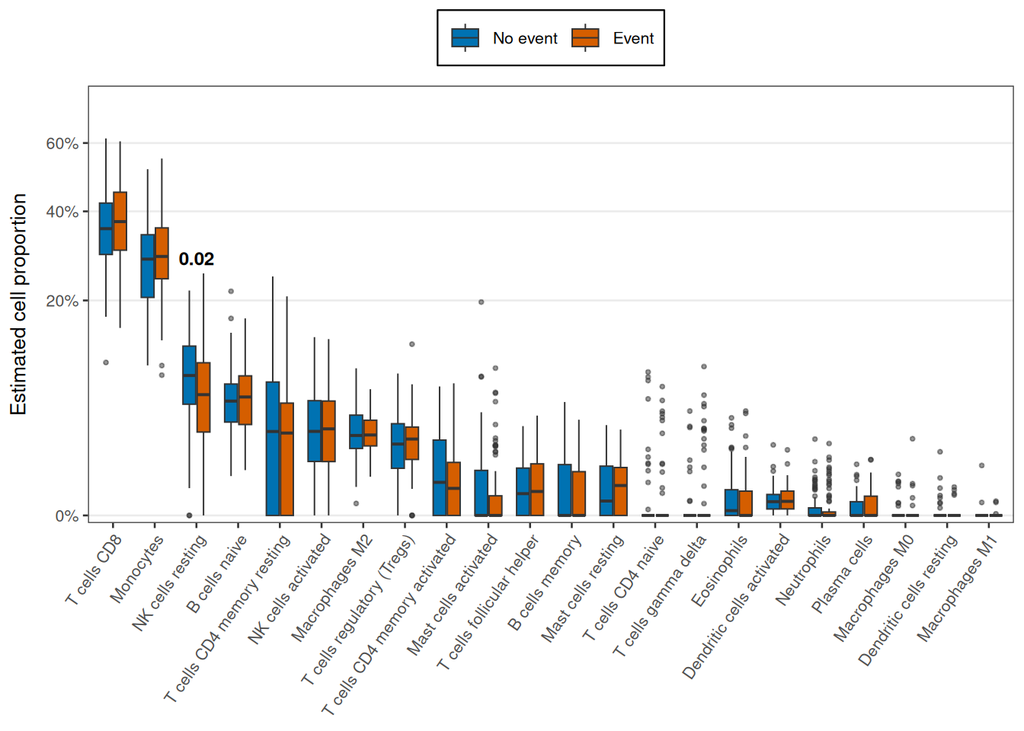

```r
group_plot_data <- deconv_long |>
    filter(outcome == "group") |>
    mutate(
        event = factor(event, levels = c(0, 1), labels = c("No event", "Event")),
        cell_type = as.character(cell_type)
    )

cell_order <- group_plot_data |>
    group_by(cell_type) |>
    summarise(mean_abundance = mean(cell_proportion), .groups = "drop") |>
    arrange(desc(mean_abundance)) |>
    pull(cell_type)

group_plot_data <- group_plot_data |>
    mutate(cell_type = factor(cell_type, levels = cell_order))

label_positions <- group_plot_data |>
    mutate(cell_type = as.character(cell_type)) |>
    group_by(cell_type) |>
    summarise(y_position = max(cell_proportion) * 1.12 + 0.002, .groups = "drop")

nominal_labels <- celltype_results |>
    filter(outcome == "group", p_value < 0.05) |>
    dplyr::select(cell_type, p_value) |>
    mutate(cell_type = as.character(cell_type)) |>
    left_join(label_positions, by = "cell_type") |>
    mutate(
        cell_type = factor(cell_type, levels = cell_order),
        p_label = format.pval(p_value, digits = 1, eps = 0.001)
    )

deconvolution_figure <- ggplot(group_plot_data, aes(x = cell_type, y = cell_proportion, fill = event)) +
    geom_boxplot(position = position_dodge2(width = 0.8, preserve = "single"),
                 width = 0.68, outlier.size = 0.7, outlier.alpha = 0.5, linewidth = 0.35) +
    geom_text(data = nominal_labels, aes(x = cell_type, y = y_position, label = p_label),
              inherit.aes = FALSE, size = 3.2, fontface = "bold") +
    scale_fill_manual(values = c("No event" = "#0072B2", "Event" = "#D55E00")) +
    scale_y_sqrt(labels = scales::label_percent(accuracy = 1),
                 expand = expansion(mult = c(0.02, 0.14))) +
    labs(x = NULL, y = "Estimated cell proportion", fill = NULL) +
    theme_bw(base_size = 10) +
    theme(
        legend.position = "top",
        legend.background = element_rect(colour = "black", fill = "white", linewidth = 0.4),
        panel.grid.minor = element_blank(),
        panel.grid.major.x = element_blank(),
        axis.text.x = element_text(angle = 55, hjust = 1, vjust = 1, size = 8),
        axis.title.y = element_text(margin = margin(r = 8)),
        plot.caption = element_text(hjust = 0, size = 8)
    )

deconvolution_figure
```

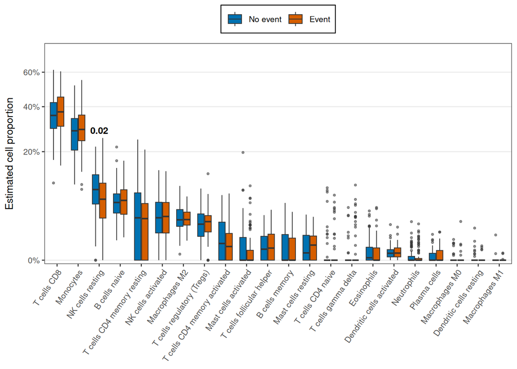

```r
# svg("../results/figS2_cell_deconvolution.svg", width = 7, height = 7)
deconvolution_figure
```

```r
# dev.off()
```